# 6371 - Analysis 1_Century21_V2

Josh

2026-04-09

# Libraries

```r
library(tidyverse)
library(dplyr)
library(ggplot2)
```

# Objective

Century 21 Ames would like to understand how the sale price of a home is related to its above-ground living area (`GrLivArea`) for homes in the **NAmes**, **Edwards**, and **BrkSide** neighborhoods. In particular, the company wants to know:

1. how sale price changes as living area increases, and
2. whether that relationship differs by neighborhood.

Because realtors prefer to discuss living area in increments of **100 square feet**, the analysis will present the effect of living area on that scale. In addition, model assumptions will be assessed, and any potentially influential observations will be identified and discussed.

# Read and Prepare Data

```r
# had to comment out in order to knit
# source("code/utils_data_prep.R")  # cleaned data prepared for linear regression

train = read.csv('/Users/joshtsamuel/SMU/DS-6371 Statistical Foundations/Housing-Prices-Regression/Data/train_cleaned.csv')

df <- train

# Restrict analysis to the three neighborhoods of interest
df_n <- df %>%
  filter(Neighborhood %in% c("NAmes", "Edwards", "BrkSide"))
```

# Initial Model Comparison

To begin, two candidate models were considered:

- a model on the original sale price scale
- a model using a log transformation of sale price

Both models allow the relationship between living area and sale price to vary by neighborhood through an interaction term.

```r
fit1 <- lm(SalePrice ~ GrLivArea * Neighborhood, data = df_n)
fit2 <- lm(log(SalePrice) ~ GrLivArea * Neighborhood, data = df_n)
```

## Diagnostic Plots for Original-Scale Model

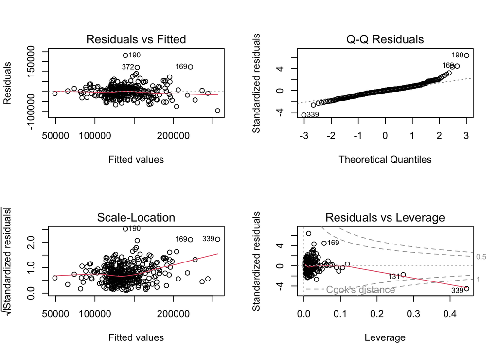

```r
par(mfrow = c(2, 2))
plot(fit1)
```

```r
par(mfrow = c(1, 1))
```

## Diagnostic Plots for Log-Scale Model

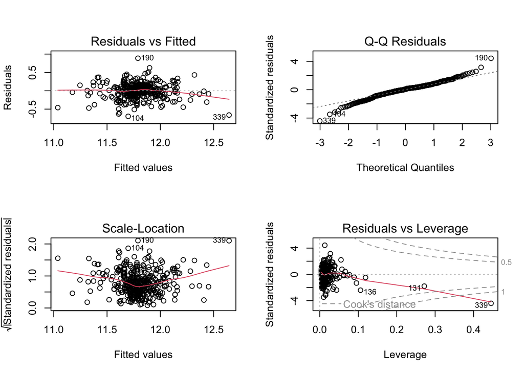

```r
par(mfrow = c(2, 2))
plot(fit2)
```

```r
par(mfrow = c(1, 1))
```

## Initial Assessment

Based on the residual diagnostics, the model using `log(SalePrice)` provided slightly better support for the linear regression assumptions. In particular, the log transformation improved the residual behavior (specifically heteroskedasticity) enough to make it the preferred model for inference.

# Investigation of Potential Influential Observations

One observation had already been flagged during earlier data cleaning.

```r
df_n[339, ]
```

```
##       Id MSSubClass MSZoning LotFrontage LotArea Street Alley LotShape
## 339 1299         60       RL         313   63887   Pave  None      IR3
##     LandContour Utilities LotConfig LandSlope Neighborhood Condition1
## 339         Bnk    AllPub    Corner       Gtl      Edwards      Feedr
##     Condition2 BldgType HouseStyle OverallQual OverallCond YearBuilt
## 339       Norm     1Fam     2Story          10           5      2008
##     YearRemodAdd RoofStyle RoofMatl Exterior1st Exterior2nd MasVnrType
## 339         2008       Hip  ClyTile      Stucco      Stucco      Stone
##     MasVnrArea ExterQual ExterCond Foundation BsmtQual BsmtCond BsmtExposure
## 339        796        Ex        TA      PConc       Ex       TA           Gd
##     BsmtFinType1 BsmtFinSF1 BsmtFinType2 BsmtFinSF2 BsmtUnfSF TotalBsmtSF
## 339          GLQ       5644          Unf          0       466        6110
##     Heating HeatingQC CentralAir Electrical X1stFlrSF X2ndFlrSF LowQualFinSF
## 339    GasA        Ex          Y      SBrkr      4692       950            0
##     GrLivArea BsmtFullBath BsmtHalfBath FullBath HalfBath BedroomAbvGr
## 339      5642            2            0        2        1            3
##     KitchenAbvGr KitchenQual TotRmsAbvGrd Functional Fireplaces FireplaceQu
## 339            1          Ex           12        Typ          3          Gd
##     GarageType GarageYrBlt GarageFinish GarageCars GarageArea GarageQual
## 339     Attchd        2008          Fin          2       1418         TA
##     GarageCond PavedDrive WoodDeckSF OpenPorchSF EnclosedPorch X3SsnPorch
## 339         TA          Y        214         292             0          0
##     ScreenPorch PoolArea PoolQC Fence MiscFeature MiscVal MoSold YrSold
## 339           0      480     Gd  None        None       0      1   2008
##     SaleType SaleCondition SalePrice
## 339      New       Partial    160000
```

To evaluate its impact, the log-scale model was refit after removing observation 339.

```r
df_n_no339 <- df_n[-339, ]

fit2_no339 <- lm(log(SalePrice) ~ GrLivArea * Neighborhood, data = df_n_no339)

summary(fit2)
```

```
##
## Call:
## lm(formula = log(SalePrice) ~ GrLivArea * Neighborhood, data = df_n)
##
## Residuals:
##     Min      1Q  Median      3Q     Max
## -0.6963 -0.1044  0.0138  0.1107  0.8862
##
## Coefficients:
##                                 Estimate Std. Error t value Pr(>|t|)
## (Intercept)                    1.079e+01  8.702e-02 124.019  < 2e-16 ***
## GrLivArea                      7.382e-04  6.892e-05  10.712  < 2e-16 ***
## NeighborhoodEdwards            6.303e-01  9.842e-02   6.405 4.49e-10 ***
## NeighborhoodNAmes              6.517e-01  9.780e-02   6.664 9.48e-11 ***
## GrLivArea:NeighborhoodEdwards -5.215e-04  7.551e-05  -6.907 2.11e-11 ***
## GrLivArea:NeighborhoodNAmes   -4.141e-04  7.620e-05  -5.435 9.88e-08 ***
## ---
## Signif. codes:  0 '***' 0.001 '**' 0.01 '*' 0.05 '.' 0.1 ' ' 1
##
## Residual standard error: 0.2012 on 377 degrees of freedom
## Multiple R-squared:  0.466,  Adjusted R-squared:  0.4589
## F-statistic: 65.79 on 5 and 377 DF,  p-value: < 2.2e-16
```

```r
summary(fit2_no339)
```

```
##
## Call:
## lm(formula = log(SalePrice) ~ GrLivArea * Neighborhood, data = df_n_no339)
##
## Residuals:
##      Min       1Q   Median       3Q      Max
## -0.72318 -0.10467  0.01484  0.11355  0.83104
##
## Coefficients:
##                                 Estimate Std. Error t value Pr(>|t|)
## (Intercept)                   10.7915940  0.0848477 127.188  < 2e-16 ***
## GrLivArea                      0.0007382  0.0000672  10.986  < 2e-16 ***
## NeighborhoodEdwards            0.4804612  0.1015110   4.733 3.14e-06 ***
## NeighborhoodNAmes              0.6517467  0.0953665   6.834 3.34e-11 ***
## GrLivArea:NeighborhoodEdwards -0.0004008  0.0000783  -5.118 4.93e-07 ***
## GrLivArea:NeighborhoodNAmes   -0.0004141  0.0000743  -5.574 4.77e-08 ***
## ---
## Signif. codes:  0 '***' 0.001 '**' 0.01 '*' 0.05 '.' 0.1 ' ' 1
##
## Residual standard error: 0.1961 on 376 degrees of freedom
## Multiple R-squared:  0.493,  Adjusted R-squared:  0.4863
## F-statistic: 73.13 on 5 and 376 DF,  p-value: < 2.2e-16
```

## Diagnostic Plots After Removing Observation 339

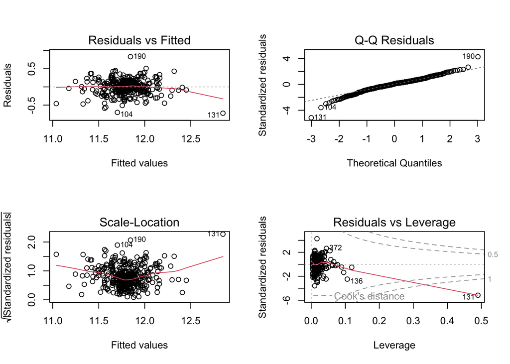

```r
par(mfrow = c(2, 2))
plot(fit2_no339)
```

```r
par(mfrow = c(1, 1))
```

After removing observation 339, another observation still appeared somewhat unusual.

```r
df_n_no339[131, ]
```

```
##      Id MSSubClass MSZoning LotFrontage LotArea Street Alley LotShape
## 131 524         60       RL         130   40094   Pave  None      IR1
##     LandContour Utilities LotConfig LandSlope Neighborhood Condition1
## 131         Bnk    AllPub    Inside       Gtl      Edwards       PosN
##     Condition2 BldgType HouseStyle OverallQual OverallCond YearBuilt
## 131       PosN     1Fam     2Story          10           5      2007
##     YearRemodAdd RoofStyle RoofMatl Exterior1st Exterior2nd MasVnrType
## 131         2008       Hip  CompShg     CemntBd     CmentBd      Stone
##     MasVnrArea ExterQual ExterCond Foundation BsmtQual BsmtCond BsmtExposure
## 131        762        Ex        TA      PConc       Ex       TA           Gd
##     BsmtFinType1 BsmtFinSF1 BsmtFinType2 BsmtFinSF2 BsmtUnfSF TotalBsmtSF
## 131          GLQ       2260          Unf          0       878        3138
##     Heating HeatingQC CentralAir Electrical X1stFlrSF X2ndFlrSF LowQualFinSF
## 131    GasA        Ex          Y      SBrkr      3138      1538            0
##     GrLivArea BsmtFullBath BsmtHalfBath FullBath HalfBath BedroomAbvGr
## 131      4676            1            0        3        1            3
##     KitchenAbvGr KitchenQual TotRmsAbvGrd Functional Fireplaces FireplaceQu
## 131            1          Ex           11        Typ          1          Gd
##     GarageType GarageYrBlt GarageFinish GarageCars GarageArea GarageQual
## 131    BuiltIn        2007          Fin          3        884         TA
##     GarageCond PavedDrive WoodDeckSF OpenPorchSF EnclosedPorch X3SsnPorch
## 131         TA          Y        208         406             0          0
##     ScreenPorch PoolArea PoolQC Fence MiscFeature MiscVal MoSold YrSold
## 131           0        0   None  None        None       0     10   2007
##     SaleType SaleCondition SalePrice
## 131      New       Partial    184750
```

## Removal of Two Outliers (ID = 1299, 524)

Both of these observations were in the **Edwards** neighborhood, and removing them would noticeably affect the fitted Edwards regression line. After reviewing the observations, we have decided that it would be best to remove the two outliers from the analysis due to them being extreme and rare cases of partial builds. These observations had Id = 1299 and 524 respectively.

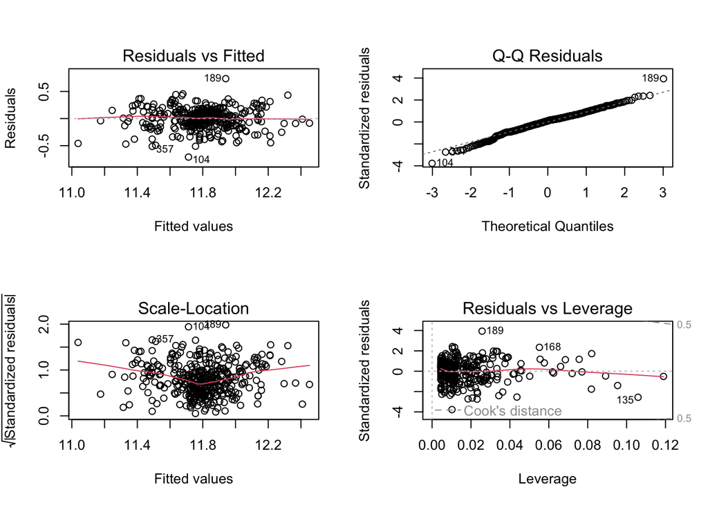

```r
df_n <- df_n %>%
  filter(!(Id %in% c(1299, 524)))
fit2 <- lm(log(SalePrice) ~ GrLivArea * Neighborhood, data = df_n)

# Diagnostic Plots
par(mfrow = c(2, 2))
plot(fit2)
```

```r
par(mfrow = c(1, 1))
```

# Final Model

Because the client prefers interpretations in units of **100 square feet**, living area was rescaled accordingly.

```r
df_n$GrLivArea100 <- df_n$GrLivArea / 100
```

A centered version of this variable was also created. Centering does **not** change the fitted values or the overall model fit. It simply makes the neighborhood coefficients easier to interpret by comparing neighborhoods at the **average living area**, rather than at 0 square feet.

```r
df_n$GrLivArea100_c <- df_n$GrLivArea100 - mean(df_n$GrLivArea100)
```

The final model used for inference was:

```r
fit_final <- lm(log(SalePrice) ~ GrLivArea100_c * Neighborhood, data = df_n)
summary(fit_final)
```

```
##
## Call:
## lm(formula = log(SalePrice) ~ GrLivArea100_c * Neighborhood,
##     data = df_n)
##
## Residuals:
##      Min       1Q   Median       3Q      Max
## -0.71071 -0.11467  0.02085  0.11453  0.73596
##
## Coefficients:
##                                     Estimate Std. Error t value Pr(>|t|)
## (Intercept)                        11.737689   0.025375 462.570  < 2e-16 ***
## GrLivArea100_c                      0.073822   0.006486  11.382  < 2e-16 ***
## NeighborhoodEdwards                -0.021873   0.031792  -0.688   0.4919
## NeighborhoodNAmes                   0.121044   0.028354   4.269 2.49e-05 ***
## GrLivArea100_c:NeighborhoodEdwards -0.019957   0.008443  -2.364   0.0186 *
## GrLivArea100_c:NeighborhoodNAmes   -0.041410   0.007171  -5.774 1.62e-08 ***
## ---
## Signif. codes:  0 '***' 0.001 '**' 0.01 '*' 0.05 '.' 0.1 ' ' 1
##
## Residual standard error: 0.1893 on 375 degrees of freedom
## Multiple R-squared:  0.5271, Adjusted R-squared:  0.5208
## F-statistic: 83.61 on 5 and 375 DF,  p-value: < 2.2e-16
```

```r
# AIC
AIC(fit_final)
```

```
## [1] -179.033
```

```r
# CV PRESS
PRESS <- sum((residuals(fit_final) / (1 - hatvalues(fit_final)))^2)
PRESS
```

```
## [1] 14.01493
```

Comparing final model’s metrics the non-log model

```r
fit_nonlog <- lm(SalePrice ~ GrLivArea100_c * Neighborhood, data = df_n)
summary(fit_nonlog)
```

```
##
## Call:
## lm(formula = SalePrice ~ GrLivArea100_c * Neighborhood, data = df_n)
##
## Residuals:
##    Min     1Q Median     3Q    Max
## -74948 -14828    960  13409 159563
##
## Coefficients:
##                                    Estimate Std. Error t value Pr(>|t|)
## (Intercept)                          131678       3596  36.623  < 2e-16 ***
## GrLivArea100_c                         8716        919   9.484  < 2e-16 ***
## NeighborhoodEdwards                   -2879       4505  -0.639  0.52316
## NeighborhoodNAmes                     12609       4018   3.138  0.00183 **
## GrLivArea100_c:NeighborhoodEdwards    -1119       1196  -0.935  0.35035
## GrLivArea100_c:NeighborhoodNAmes      -3285       1016  -3.233  0.00134 **
## ---
## Signif. codes:  0 '***' 0.001 '**' 0.01 '*' 0.05 '.' 0.1 ' ' 1
##
## Residual standard error: 26830 on 375 degrees of freedom
## Multiple R-squared:  0.5125, Adjusted R-squared:  0.506
## F-statistic: 78.83 on 5 and 375 DF,  p-value: < 2.2e-16
```

```r
# AIC
AIC(fit_nonlog)
```

```
## [1] 8859.372
```

```r
# CV PRESS
PRESS <- sum((residuals(fit_nonlog) / (1 - hatvalues(fit_nonlog)))^2)
PRESS
```

```
## [1] 282791737788
```

Note that all coefficients were statistically signficant at an alpha = 0.05 level of signficance **except** NeighborhoodEdwards.

## Confidence Intervals for Model Coefficients

```r
confint(fit_final)
```

```
##                                          2.5 %       97.5 %
## (Intercept)                        11.68779439 11.787584524
## GrLivArea100_c                      0.06106879  0.086575774
## NeighborhoodEdwards                -0.08438590  0.040639673
## NeighborhoodNAmes                   0.06529147  0.176797493
## GrLivArea100_c:NeighborhoodEdwards -0.03655777 -0.003355877
## GrLivArea100_c:NeighborhoodNAmes   -0.05551067 -0.027308986
```

# Diagnostic Plots for Final Model

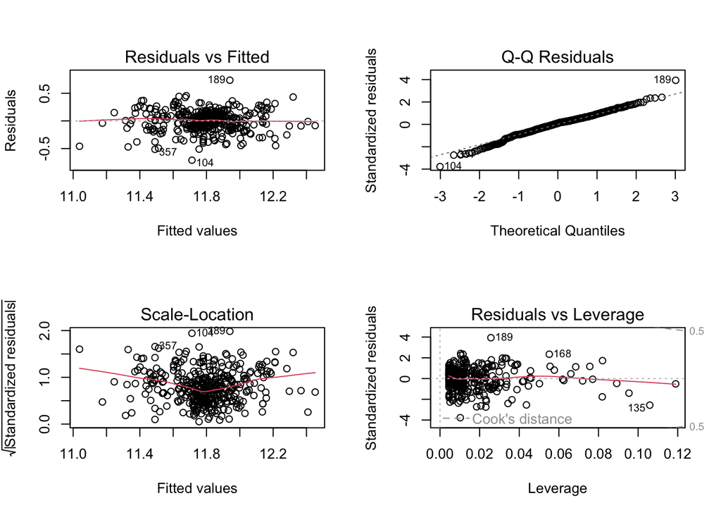

```r
par(mfrow = c(2, 2))
plot(fit_final)
```

```r
par(mfrow = c(1, 1))
```

## Assumption Check Summary

Based on the diagnostic plots for the final model:

- the relationship between the predictors and `log(SalePrice)` appears reasonably linear
- the residual variance is more stable than in the original-scale model
- the residual distribution appears more consistent with normality
- while a small number of observations may be somewhat influential, there was not sufficient justification to remove them from the analysis

Overall, the log-scale model appears to provide an acceptable fit for answering the client’s question.

# Interpreting the Final Model

Because the response variable is `log(SalePrice)`, the effect of living area is most naturally interpreted in terms of **approximate percent changes** in sale price.

For the **reference neighborhood (BrkSide)**, the coefficient of `GrLivArea100_c` represents the estimated change in log sale price associated with an additional 100 square feet of living area. Converting this coefficient to a percent change can be done as follows:

```r
pct_change <- 100 * (exp(coef(fit_final)) - 1)

data.frame(
  Term = names(pct_change),
  Percent_Change = paste0(round(pct_change, 2), "%")
)
```

```
##                                 Term Percent_Change
## 1                        (Intercept)    12520171.9%
## 2                     GrLivArea100_c          7.66%
## 3                NeighborhoodEdwards         -2.16%
## 4                  NeighborhoodNAmes         12.87%
## 5 GrLivArea100_c:NeighborhoodEdwards         -1.98%
## 6   GrLivArea100_c:NeighborhoodNAmes         -4.06%
```

For the other neighborhoods, the living area slope must be adjusted by adding the appropriate interaction term.

## Neighborhood-Specific Slopes

When **BrkSide** is the reference neighborhood:

- **BrkSide slope** = `GrLivArea100_c`
- **Edwards slope** = `GrLivArea100_c + GrLivArea100_c:NeighborhoodEdwards`
- **NAmes slope** = `GrLivArea100_c + GrLivArea100_c:NeighborhoodNAmes`

The code below computes the neighborhood-specific effect of an additional 100 square feet and expresses each effect as an approximate percent change in sale price.

```r
coefs <- coef(fit_final)

beta_brkside <- coefs["GrLivArea100_c"]
beta_edwards <- coefs["GrLivArea100_c"] + coefs["GrLivArea100_c:NeighborhoodEdwards"]
beta_names   <- coefs["GrLivArea100_c"] + coefs["GrLivArea100_c:NeighborhoodNAmes"]

slope_summary <- data.frame(
  Neighborhood = c("BrkSide", "Edwards", "NAmes"),
  Percent_Change = paste0(
    round(100 * (exp(c(beta_brkside, beta_edwards, beta_names)) - 1), 2),
    "%"
  )
)

slope_summary
```

```
##   Neighborhood Percent_Change
## 1      BrkSide          7.66%
## 2      Edwards          5.53%
## 3        NAmes          3.29%
```

# Confidence Intervals for Neighborhood-Specific Slopes

Because the Edwards and NAmes slopes are sums of regression coefficients, their confidence intervals must be computed using linear combinations.

```r
library(multcomp)
K <- rbind(
  "BrkSide" = c(0, 1, 0, 0, 0, 0),
  "Edwards" = c(0, 1, 0, 0, 1, 0),
  "NAmes"   = c(0, 1, 0, 0, 0, 1)
)

glht_slopes <- glht(fit_final, linfct = K)
slope_ci <- confint(glht_slopes)
```

The intervals returned above are on the **log scale**. The following code converts the point estimates and confidence limits to approximate percent changes in sale price per additional 100 square feet.

```r
slope_est <- coef(glht_slopes)
slope_lwr <- slope_ci$confint[, "lwr"]
slope_upr <- slope_ci$confint[, "upr"]

slope_results <- data.frame(
  Neighborhood = names(slope_est),
  Percent_Change = paste0(round(100 * (exp(slope_est) - 1), 2), "%"),
  CI_Lower = paste0(round(100 * (exp(slope_lwr) - 1), 2), "%"),
  CI_Upper = paste0(round(100 * (exp(slope_upr) - 1), 2), "%")
)

slope_results
```

```
##   Neighborhood Percent_Change CI_Lower CI_Upper
## 1      BrkSide          7.66%       6%    9.35%
## 2      Edwards          5.53%    4.18%    6.91%
## 3        NAmes          3.29%    2.54%    4.05%
```

# Optional Predictive Comparison

Although the main purpose of this analysis is inference rather than prediction, a simple train/test split was used to compare predictive performance between the original-scale and log-scale models.

These predictive results should be interpreted cautiously.

```r
set.seed(123)

n <- nrow(df_n)
train_idx <- sample(seq_len(n), size = 0.7 * n)

train_df <- df_n[train_idx, ]
test_df  <- df_n[-train_idx, ]

fit1_pred <- lm(SalePrice ~ GrLivArea * Neighborhood, data = train_df)
fit2_pred <- lm(log(SalePrice) ~ GrLivArea * Neighborhood, data = train_df)

pred_fit1 <- predict(fit1_pred, newdata = test_df)

pred_log <- predict(fit2_pred, newdata = test_df)
smear <- mean(exp(residuals(fit2_pred)))
pred_fit2 <- exp(pred_log) * smear

rmse <- function(actual, pred) {
  sqrt(mean((actual - pred)^2))
}

mae <- function(actual, pred) {
  mean(abs(actual - pred))
}

r2_test <- function(actual, pred) {
  1 - sum((actual - pred)^2) / sum((actual - mean(actual))^2)
}

results <- data.frame(
  Model = c("Original Scale", "Log Scale Back-Transformed"),
  RMSE = c(
    rmse(test_df$SalePrice, pred_fit1),
    rmse(test_df$SalePrice, pred_fit2)
  ),
  MAE = c(
    mae(test_df$SalePrice, pred_fit1),
    mae(test_df$SalePrice, pred_fit2)
  ),
  Test_R2 = c(
    r2_test(test_df$SalePrice, pred_fit1),
    r2_test(test_df$SalePrice, pred_fit2)
  )
)

results
```

```
##                        Model     RMSE      MAE   Test_R2
## 1             Original Scale 25933.71 19770.49 0.4939807
## 2 Log Scale Back-Transformed 26019.40 19820.64 0.4906314
```

In this particular split, the original-scale model may appear to perform somewhat better on prediction metrics. However, because the log-scale model better satisfies the regression assumptions, it remains the preferred model for inference.

# Conclusion

For homes in **NAmes**, **Edwards**, and **BrkSide**, sale price is clearly related to above-ground living area, and the fitted model allows that relationship to differ by neighborhood.

The final model used `log(SalePrice)` as the response and expressed living area in units of **100 square feet**. This made the regression assumptions more reasonable while also allowing the effect of living area to be interpreted in a way that is meaningful for the client.

Based on the fitted interaction model:

- the relationship between living area and sale price is statistically significant
- the estimated effect of an additional 100 square feet can be quantified separately for each neighborhood
- the interaction terms allow us to assess whether that relationship differs across neighborhoods

Overall, the analysis suggests that larger living area is associated with higher sale price, but the strength of that relationship may vary depending on whether the house is located in **NAmes**, **Edwards**, or **BrkSide**.